# 國泰世華面試簡報

2019-07-16

賴彥廷

## 說明：

- 資料來源：使用UCI Adult Data Set。 http://archive.ics.uci.edu/ml/datasets/Adult
- 分析流程：
  1. 資料檢視
  2. 資料工程
  3. 建立模型

# 零、事前準備

## Imports

```python
import numpy as np
import pandas as pd
import seaborn as sns
import matplotlib.pyplot as plt
import warnings
import xgboost as xgb
warnings.filterwarnings(action='ignore', category=DeprecationWarning)

from sklearn.preprocessing import StandardScaler, MinMaxScaler
from sklearn.model_selection import train_test_split, GridSearchCV, cross_val_score, KFold
from sklearn.externals import joblib
from sklearn.neighbors import KNeighborsClassifier
from sklearn.tree import DecisionTreeClassifier
from sklearn.ensemble import RandomForestClassifier, AdaBoostClassifier, GradientBoostingClassifier, ExtraTreesClassifier
from sklearn.metrics import accuracy_score, log_loss, confusion_matrix, make_scorer
from sklearn.feature_selection import SelectFromModel
from sklearn.linear_model import LogisticRegression

from keras import layers
from keras import optimizers
from keras.models import Sequential, load_model
from keras.layers import Dense, Dropout
from keras.optimizers import Adam, SGD, RMSprop, Adagrad

import plotly.offline as py
py.init_notebook_mode(connected=True)
import plotly.graph_objs as go
import plotly.tools as tls
```

## Functions

```python
def plot_history(history):
    acc = history.history['acc']
    val_acc = history.history['val_acc']
    loss = history.history['loss']
    val_loss = history.history['val_loss']
    x = range(1, len(acc) + 1)
    plt.figure(figsize=(12, 5))
    plt.subplot(1, 2, 1)
    plt.plot(x, acc, 'b', label='Training acc')
    plt.plot(x, val_acc, 'r', label='Validation acc')
    plt.title('Training and validation accuracy')
    plt.legend()
    plt.subplot(1, 2, 2)
    plt.plot(x, loss, 'b', label='Training loss')
    plt.plot(x, val_loss, 'r', label='Validation loss')
    plt.title('Training and validation loss')
    plt.legend()

def train_to_test_split(train_x, train_y):
    sc = MinMaxScaler()
    train_x = sc.fit_transform(train_x)
    joblib.dump(sc.fit(train_x), scaler_filename)
    return train_test_split(train_x, train_y, test_size=0.3, random_state=SEED)

def grid_search(clf, parameters, X_train, y_train):
    acc_scorer = make_scorer(accuracy_score)
    grid_obj = GridSearchCV(clf, parameters, scoring=acc_scorer, n_jobs=-1, cv=5)
    grid_obj = grid_obj.fit(X_train, y_train.values.ravel())
    clf = grid_obj.best_estimator_
    return(clf)

def grid_classifier(clf):
    clf_name = clf.__class__.__name__
    parameters = parameter_set(clf_name)
    print(parameters)
    # return predictions from gird search best model
    clf = grid_search(clf, parameters, X_train, y_train)
    print('-'*5)
    print('Get Grid Parameters')
    print(clf.get_params())
    # fit best model
    clf.fit(X_train, y_train.values.ravel())
    model_name = 'model/'+ clf_name + 'Grid' +'_00001.pkl'
    joblib.dump(clf, model_name)
    predictions = clf.predict(X_test)
    if clf_name == 'XGBClassifier':
        predictions = [value for value in predictions]
    return clf, predictions

def get_oof(clf, X_train, y_train, X_test):
    oof_train = np.zeros((ntrain,))
    oof_test = np.zeros((ntest,))
    oof_test_skf = np.empty((NFOLDS, ntest))
    i = 0
    for train_index, test_index in kf.split(X_train):
        x_tr = X_train[train_index]
        y_tr = y_train.values.ravel()[train_index]
        x_te = X_train[test_index]
        clf.fit(x_tr, y_tr)
        oof_train[test_index] = clf.predict(x_te)
        oof_test_skf[i, :] = clf.predict(X_test)
        i += 1
    oof_test[:] = oof_test_skf.mean(axis=0)
    return oof_train.reshape(-1, 1), oof_test.reshape(-1, 1)

def parameter_set(clf_name):
    if clf_name == 'RandomForestClassifier':
        parameters = {'n_estimators': [100, 150, 200],
#               'max_features': ['log2', 'sqrt','auto'],
              'criterion': ['entropy', 'gini'],
#               'max_depth': list(range(2,10)),
#               'min_samples_split': list(range(2,5)),
#               'min_samples_leaf': list(range(1,5)),
              'n_jobs': [-1],
              'verbose': [1]
             }
    if clf_name == 'DecisionTreeClassifier':
        parameters = {
              'max_depth': list(range(2,10)),
              'min_samples_split': list(range(2,10))
             }
    if clf_name == 'AdaBoostClassifier':
        parameters = {
            "n_estimators" : [150, 200],
            "algorithm" :  ["SAMME", "SAMME.R"],
            'learning_rate': [0.2, 0.5, 0.9]
             }
    if clf_name == 'GradientBoostingClassifier':
        parameters = {
            "loss":["deviance"],
            "learning_rate": [0.2, 0.5, 0.9],
#             "min_samples_split": list(range(2,5)),
#             "min_samples_leaf": list(range(1,5)),
            "max_depth": [3, 8],
#             "max_features":["log2","sqrt"],
#             "criterion": ["friedman_mse",  "mae"],
#             "subsample": [0.5, 0.8, 0.9, 1.0],
#             "n_estimators": [100, 150]
             }
    if clf_name == 'XGBClassifier':
        parameters = {
            'learning_rate': [0.2, 0.5, 0.9],
#             'max_depth': list(range(5,10)),
#             'min_child_weight': list(range(3,10)),
            'gamma': np.linspace(0, 0.9, 3),
#             'subsample': [0.8, 0.9],
#             'colsample_bytree': [0.3, 0.4, 0.5 , 0.7, 0.8, 0.9],
            'objective': ['binary:logistic']
        }
    if clf_name == 'ExtraTreesClassifier':
        parameters = {
            "n_estimators" : [100, 150, 200],
            'criterion': ['entropy', 'gini']
        }
    return(parameters)
```

## Load data

```python
# Dirs -------------------------------------------
scaler_filename = "model/scaler.save"

# Config -----------------------------------------
SEED = 111
NFOLDS = 5

# Load Data --------------------------------------
dt = pd.read_csv("data/adult.data.csv").sample(frac=1)
```

# 1. 探索性資料分析

## 1.1 資料欄位

- **age.** 年齡
- **workclass.** 職務屬性
- **fnlwgt.** 權數
- **education.** 學歷
- **education_num.** 學歷等級
- **marital_status.** 婚姻狀況
- **occupation.** 職業
- **relationship.** 家庭狀況
- **race.** 種族
- **sex.** 性別
- **capital_gain.** 資本收益
- **capital_loss.** 資本損失
- **hours_per_week.** 每週工時
- **native_cuntry.** 國籍
- **salary.** 薪資水準，重新編碼為 [<=50K, >50K] -> [0, 1]

### 1.1.1 預覽部分資料

```python
dt.head()
```

|  | age | workclass | fnlwgt | education | education_num | marital_status | occupation | relationship | race | sex | capital_gain | capital_loss | hours_per_week | native_cuntry | salary |
| --- | --- | --- | --- | --- | --- | --- | --- | --- | --- | --- | --- | --- | --- | --- | --- |
| 15800 | 38 | Private | 143538 | HS-grad | 9 | Never-married | Machine-op-inspct | Not-in-family | White | Female | 0 | 0 | 40 | United-States | <=50K |
| 6736 | 22 | Private | 199555 | Some-college | 10 | Never-married | Farming-fishing | Own-child | White | Male | 0 | 0 | 25 | United-States | <=50K |
| 14296 | 37 | Private | 124293 | Some-college | 10 | Married-civ-spouse | Adm-clerical | Husband | White | Male | 0 | 0 | 50 | United-States | <=50K |
| 12084 | 40 | State-gov | 269733 | Assoc-voc | 11 | Never-married | Craft-repair | Not-in-family | White | Male | 0 | 0 | 40 | United-States | <=50K |
| 18777 | 54 | Private | 225307 | 11th | 7 | Divorced | Craft-repair | Own-child | White | Female | 0 | 0 | 50 | United-States | >50K |

### 1.1.2 遺漏值整理

- 此資料集以'?'作為遺漏值標記，因此以'NA'來取代。
- 資料內存在空白，以strip處裡。
- 以0取代salary欄位內'<=50K'；以1取代salary欄位內'>50K'。

  其中>50K資料筆數占比約24%，因此不需做資料不平衡之處理。

```python
str_column = []
num_column = []
for x in dt.columns:
    if dt[x].dtypes == 'object':
        dt[x] = dt[x].str.strip()
        dt[x].replace('?','NA',inplace=True)
        str_column.append(x)
    else:
        num_column.append(x)

dt['salary'].replace('>50K', 1, inplace=True)
dt['salary'].replace('<=50K', 0, inplace=True)
print(dt['salary'].value_counts())
print('>50K比例：',dt['salary'].value_counts()[1]/(dt['salary'].value_counts()[0]+dt['salary'].value_counts()[1]))
```

```
0    24720
1     7841
Name: salary, dtype: int64
>50K比例： 0.2408095574460244
```

### 1.1.3 數值變數

- Adult資料集內年齡、權重、教育水準等級、資本收益、資本損失與每週工時為數值資料，其餘為類別資料。

```python
dt.describe()
```

|  | age | fnlwgt | education_num | capital_gain | capital_loss | hours_per_week | salary |
| --- | --- | --- | --- | --- | --- | --- | --- |
| count | 32561.000000 | 3.256100e+04 | 32561.000000 | 32561.000000 | 32561.000000 | 32561.000000 | 32561.000000 |
| mean | 38.581647 | 1.897784e+05 | 10.080679 | 1077.648844 | 87.303830 | 40.437456 | 0.240810 |
| std | 13.640433 | 1.055500e+05 | 2.572720 | 7385.292085 | 402.960219 | 12.347429 | 0.427581 |
| min | 17.000000 | 1.228500e+04 | 1.000000 | 0.000000 | 0.000000 | 1.000000 | 0.000000 |
| 25% | 28.000000 | 1.178270e+05 | 9.000000 | 0.000000 | 0.000000 | 40.000000 | 0.000000 |
| 50% | 37.000000 | 1.783560e+05 | 10.000000 | 0.000000 | 0.000000 | 40.000000 | 0.000000 |
| 75% | 48.000000 | 2.370510e+05 | 12.000000 | 0.000000 | 0.000000 | 45.000000 | 0.000000 |
| max | 90.000000 | 1.484705e+06 | 16.000000 | 99999.000000 | 4356.000000 | 99.000000 | 1.000000 |

- 這些連續變數之間的相關係數均不高，適合使用在迴歸分析上。
- 其中fnlwgt與薪資水準相關度很低，建立模型時將移除此欄位。

```python
cont_col = [x for x in dt.describe().columns]
corr = dt[cont_col].corr()
corr.style.background_gradient(cmap='coolwarm').set_precision(2)
```

|  | age | fnlwgt | education_num | capital_gain | capital_loss | hours_per_week | salary |
| --- | --- | --- | --- | --- | --- | --- | --- |
| age | 1 | -0.077 | 0.037 | 0.078 | 0.058 | 0.069 | 0.23 |
| fnlwgt | -0.077 | 1 | -0.043 | 0.00043 | -0.01 | -0.019 | -0.0095 |
| education_num | 0.037 | -0.043 | 1 | 0.12 | 0.08 | 0.15 | 0.34 |
| capital_gain | 0.078 | 0.00043 | 0.12 | 1 | -0.032 | 0.078 | 0.22 |
| capital_loss | 0.058 | -0.01 | 0.08 | -0.032 | 1 | 0.054 | 0.15 |
| hours_per_week | 0.069 | -0.019 | 0.15 | 0.078 | 0.054 | 1 | 0.23 |
| salary | 0.23 | -0.0095 | 0.34 | 0.22 | 0.15 | 0.23 | 1 |

```python
dt = dt.drop(['fnlwgt'], axis = 1 )
```

以簡單Logit回歸先看一下對於薪資水準的影響，  
資料標準化後以資本收益對於薪資水準影響最大，  
在後續敘述統計中可以知道**自營者薪資水準較高**，  
可符合目前觀察到的現象。

```python
cont_col = [x for x in dt.describe().columns][:-1]
X_logit = dt[cont_col]
y_logit = dt['salary']
sc = StandardScaler()
X_logit = pd.DataFrame(sc.fit_transform(X_logit))
X_logit.describe()
```

|  | 0 | 1 | 2 | 3 | 4 |
| --- | --- | --- | --- | --- | --- |
| count | 3.256100e+04 | 3.256100e+04 | 3.256100e+04 | 3.256100e+04 | 3.256100e+04 |
| mean | -1.163823e-16 | -5.570246e-16 | -1.765528e-16 | 1.943768e-16 | 5.750615e-16 |
| std | 1.000015e+00 | 1.000015e+00 | 1.000015e+00 | 1.000015e+00 | 1.000015e+00 |
| min | -1.582206e+00 | -3.529656e+00 | -1.459205e-01 | -2.166595e-01 | -3.194030e+00 |
| 25% | -7.757679e-01 | -4.200596e-01 | -1.459205e-01 | -2.166595e-01 | -3.542945e-02 |
| 50% | -1.159546e-01 | -3.136003e-02 | -1.459205e-01 | -2.166595e-01 | -3.542945e-02 |
| 75% | 6.904838e-01 | 7.460392e-01 | -1.459205e-01 | -2.166595e-01 | 3.695194e-01 |
| max | 3.769612e+00 | 2.300838e+00 | 1.339458e+01 | 1.059351e+01 | 4.742967e+00 |

```python
clf = LogisticRegression(random_state=0, solver='lbfgs',multi_class='multinomial').fit(X_logit, y_logit)
```

```python
print(cont_col)
print(clf.coef_)
```

```
['age', 'education_num', 'capital_gain', 'capital_loss', 'hours_per_week']
[[0.29334828 0.41506075 1.1737482  0.14079209 0.25136639]]
```

### 1.1.4 類別變數

- workclass以Private占比最高。
- education以HS-grad、Some-college、Bachelors較高。
- marital_status以Married-civ-spouse最高。(已婚平民配偶)
- native_cuntry大部分為United-States。
- 各類別欄位遺漏值占比皆不高，均以NA代替後納入模型訓練資料集。
- 後續會將類別變數轉為虛擬變數。

```python
for x in dt.columns:
    if dt[x].dtypes == 'object':
        print('='*20,x,'='*20)
        print(dt[x].value_counts())
```

```
==================== workclass ====================
Private             22696
Self-emp-not-inc     2541
Local-gov            2093
NA                   1836
State-gov            1298
Self-emp-inc         1116
Federal-gov           960
Without-pay            14
Never-worked            7
Name: workclass, dtype: int64
==================== education ====================
HS-grad         10501
Some-college     7291
Bachelors        5355
Masters          1723
Assoc-voc        1382
11th             1175
Assoc-acdm       1067
10th              933
7th-8th           646
Prof-school       576
9th               514
12th              433
Doctorate         413
5th-6th           333
1st-4th           168
Preschool          51
Name: education, dtype: int64
==================== marital_status ====================
Married-civ-spouse       14976
Never-married            10683
Divorced                  4443
Separated                 1025
Widowed                    993
Married-spouse-absent      418
Married-AF-spouse           23
Name: marital_status, dtype: int64
==================== occupation ====================
Prof-specialty       4140
```

[output cut: 63 more lines]

```
France                           29
Ecuador                          28
Ireland                          24
Hong                             20
Trinadad&Tobago                  19
Cambodia                         19
Thailand                         18
Laos                             18
Yugoslavia                       16
Outlying-US(Guam-USVI-etc)       14
Hungary                          13
Honduras                         13
Scotland                         12
Holand-Netherlands                1
Name: native_cuntry, dtype: int64
```

## 1.2 各欄位檢視

### 1.2.1 Sex

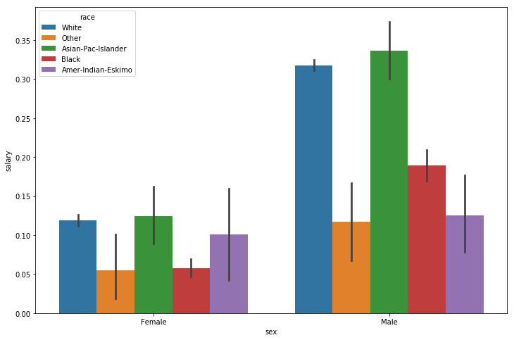

```python
# plot
plt.figure(figsize=(12,8))
sns.barplot(x='sex', y='salary', data=dt, hue='race')
```

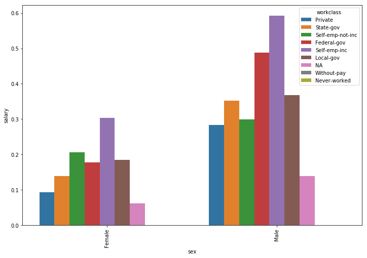

```python
plt.figure(figsize=(12,8))
sns.barplot(x='sex', y='salary', data=dt, ci=None, hue='workclass')
plt.xticks(rotation=90)
```

### 1.2.2 workclass

- 單以工作性質來看，同樣是自營者薪資最高，其次是聯邦公職人員。

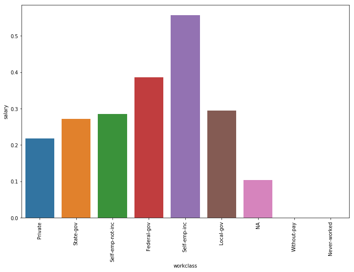

```python
plt.figure(figsize=(12,8))
sns.barplot(x='workclass', y='salary', data=dt, ci=None)
plt.xticks(rotation=90)
```

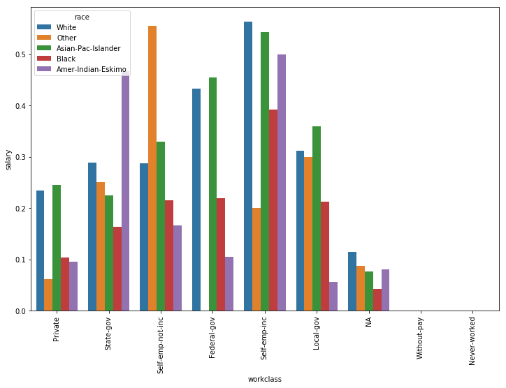

```python
plt.figure(figsize=(12,8))
sns.barplot(x='workclass', y='salary', data=dt, ci=None, hue='race')
plt.xticks(rotation=90)
```

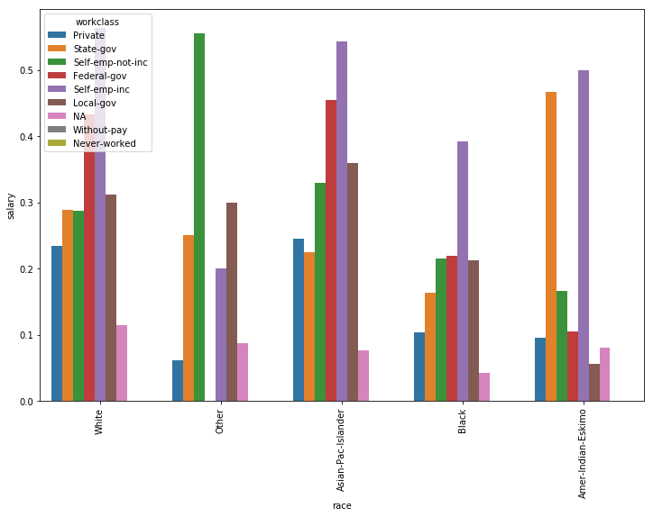

```python
plt.figure(figsize=(12,8))
sns.barplot(x='race', y='salary', data=dt, ci=None, hue='workclass')
plt.xticks(rotation=90)
```

### 1.2.3 education

- 與一般認知相同，教育水準越高則薪資水準越高。
- 12th以下教育水準薪資水準相當，後續建立模型時可選擇合併類別，此次簡報不做處理。

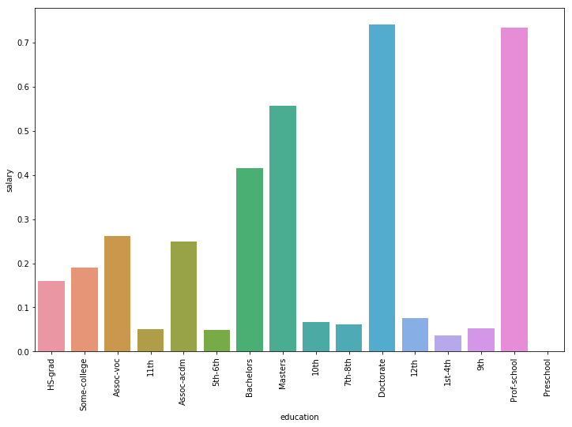

```python
plt.figure(figsize=(12,8))
sns.barplot(x='education', y='salary', data=dt, ci=None)
plt.xticks(rotation=90)
```

### 1.2.4 occupation

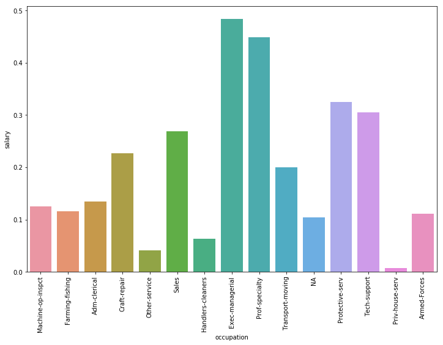

```python
plt.figure(figsize=(12,8))
sns.barplot(x='occupation', y='salary', data=dt, ci=None)
plt.xticks(rotation=90)
```

### 1.2.5 relationship

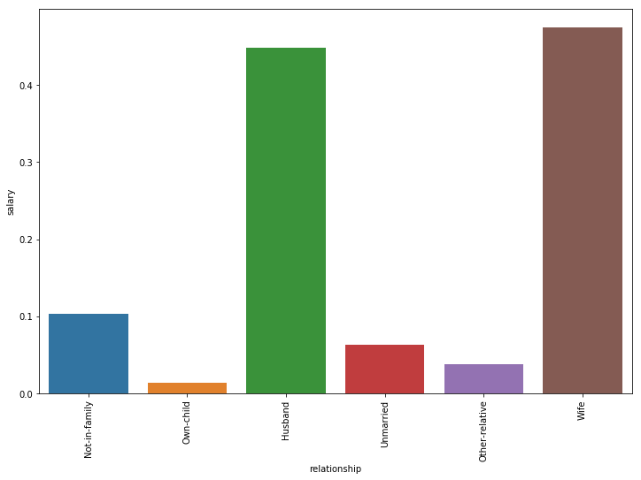

```python
plt.figure(figsize=(12,8))
sns.barplot(x='relationship', y='salary', data=dt, ci=None)
plt.xticks(rotation=90)
```

## 1.3 小結

- 數值變數除了fnlwgt之外均與薪資水準有相關，後續建模均納入作為變數使用。
- 類別變數分組都可看到明顯的薪資水準差異，後續轉化為虛擬變數後納入模型變數。

# 2. 建立模型

```python
dt.head()
```

|  | age | workclass | education | education_num | marital_status | occupation | relationship | race | sex | capital_gain | capital_loss | hours_per_week | native_cuntry | salary |
| --- | --- | --- | --- | --- | --- | --- | --- | --- | --- | --- | --- | --- | --- | --- |
| 15800 | 38 | Private | HS-grad | 9 | Never-married | Machine-op-inspct | Not-in-family | White | Female | 0 | 0 | 40 | United-States | 0 |
| 6736 | 22 | Private | Some-college | 10 | Never-married | Farming-fishing | Own-child | White | Male | 0 | 0 | 25 | United-States | 0 |
| 14296 | 37 | Private | Some-college | 10 | Married-civ-spouse | Adm-clerical | Husband | White | Male | 0 | 0 | 50 | United-States | 0 |
| 12084 | 40 | State-gov | Assoc-voc | 11 | Never-married | Craft-repair | Not-in-family | White | Male | 0 | 0 | 40 | United-States | 0 |
| 18777 | 54 | Private | 11th | 7 | Divorced | Craft-repair | Own-child | White | Female | 0 | 0 | 50 | United-States | 1 |

## 2.1 資料工程

### 2.1.1 類別變數

- 類別變數改為虛擬變數

```python
str_column = str_column[:-1]
print(str_column)
for x in str_column:
    dummies = pd.get_dummies( dt[x], prefix=x)
    dt = pd.concat( [dt, dummies], axis = 1 )
dt = dt.drop( str_column, axis = 1 )
dt = dt.drop(['education_num'], axis = 1 )
dt.head()
```

```
['workclass', 'education', 'marital_status', 'occupation', 'relationship', 'race', 'sex', 'native_cuntry']
```

|  | age | capital_gain | capital_loss | hours_per_week | salary | workclass_Federal-gov | workclass_Local-gov | workclass_NA | workclass_Never-worked | workclass_Private | ... | native_cuntry_Portugal | native_cuntry_Puerto-Rico | native_cuntry_Scotland | native_cuntry_South | native_cuntry_Taiwan | native_cuntry_Thailand | native_cuntry_Trinadad&Tobago | native_cuntry_United-States | native_cuntry_Vietnam | native_cuntry_Yugoslavia |
| --- | --- | --- | --- | --- | --- | --- | --- | --- | --- | --- | --- | --- | --- | --- | --- | --- | --- | --- | --- | --- | --- |
| 15800 | 38 | 0 | 0 | 40 | 0 | 0 | 0 | 0 | 0 | 1 | ... | 0 | 0 | 0 | 0 | 0 | 0 | 0 | 1 | 0 | 0 |
| 6736 | 22 | 0 | 0 | 25 | 0 | 0 | 0 | 0 | 0 | 1 | ... | 0 | 0 | 0 | 0 | 0 | 0 | 0 | 1 | 0 | 0 |
| 14296 | 37 | 0 | 0 | 50 | 0 | 0 | 0 | 0 | 0 | 1 | ... | 0 | 0 | 0 | 0 | 0 | 0 | 0 | 1 | 0 | 0 |
| 12084 | 40 | 0 | 0 | 40 | 0 | 0 | 0 | 0 | 0 | 0 | ... | 0 | 0 | 0 | 0 | 0 | 0 | 0 | 1 | 0 | 0 |
| 18777 | 54 | 0 | 0 | 50 | 1 | 0 | 0 | 0 | 0 | 1 | ... | 0 | 0 | 0 | 0 | 0 | 0 | 0 | 1 | 0 | 0 |

5 rows × 107 columns

### 2.1.2 數值變數

- 數值變數做標準化處理。

```python
num_column.remove('fnlwgt')
num_column.remove('education_num')
print(num_column)
num_column_sc = StandardScaler()
num_column_scaler = pd.DataFrame(num_column_sc.fit_transform(dt[num_column]))
num_column_scaler.columns = num_column
num_column_scaler.head()
```

```
['age', 'capital_gain', 'capital_loss', 'hours_per_week']
```

|  | age | capital_gain | capital_loss | hours_per_week |
| --- | --- | --- | --- | --- |
| 0 | -0.042642 | -0.14592 | -0.21666 | -0.035429 |
| 1 | -1.215643 | -0.14592 | -0.21666 | -1.250276 |
| 2 | -0.115955 | -0.14592 | -0.21666 | 0.774468 |
| 3 | 0.103983 | -0.14592 | -0.21666 | -0.035429 |
| 4 | 1.130359 | -0.14592 | -0.21666 | 0.774468 |

```python
dt = dt.drop( num_column, axis = 1 )
dt = pd.concat( [dt, num_column_scaler], axis = 1 )

dt.head()
```

|  | salary | workclass_Federal-gov | workclass_Local-gov | workclass_NA | workclass_Never-worked | workclass_Private | workclass_Self-emp-inc | workclass_Self-emp-not-inc | workclass_State-gov | workclass_Without-pay | ... | native_cuntry_Taiwan | native_cuntry_Thailand | native_cuntry_Trinadad&Tobago | native_cuntry_United-States | native_cuntry_Vietnam | native_cuntry_Yugoslavia | age | capital_gain | capital_loss | hours_per_week |
| --- | --- | --- | --- | --- | --- | --- | --- | --- | --- | --- | --- | --- | --- | --- | --- | --- | --- | --- | --- | --- | --- |
| 0 | 0 | 0 | 0 | 0 | 0 | 0 | 0 | 0 | 1 | 0 | ... | 0 | 0 | 0 | 1 | 0 | 0 | -0.042642 | -0.14592 | -0.21666 | -0.035429 |
| 1 | 0 | 0 | 0 | 0 | 0 | 0 | 0 | 1 | 0 | 0 | ... | 0 | 0 | 0 | 1 | 0 | 0 | -1.215643 | -0.14592 | -0.21666 | -1.250276 |
| 2 | 0 | 0 | 0 | 0 | 0 | 1 | 0 | 0 | 0 | 0 | ... | 0 | 0 | 0 | 1 | 0 | 0 | -0.115955 | -0.14592 | -0.21666 | 0.774468 |
| 3 | 0 | 0 | 0 | 0 | 0 | 1 | 0 | 0 | 0 | 0 | ... | 0 | 0 | 0 | 1 | 0 | 0 | 0.103983 | -0.14592 | -0.21666 | -0.035429 |
| 4 | 0 | 0 | 0 | 0 | 0 | 1 | 0 | 0 | 0 | 0 | ... | 0 | 0 | 0 | 0 | 0 | 0 | 1.130359 | -0.14592 | -0.21666 | 0.774468 |

5 rows × 107 columns

### 2.1.3 隨機森林變數重要性

```python
clf = RandomForestClassifier()
try_col = [x for x in dt.columns if x != 'salary']
x_try = dt[try_col]
clf.fit(x_try, dt['salary'].values.ravel())
pd.DataFrame({'Name':[x for x in dt.columns if x != 'salary'],
              'importance' : clf.feature_importances_}).sort_values(by='importance', ascending=False).head(10)
```

|  | Name | importance |
| --- | --- | --- |
| 102 | age | 0.255753 |
| 105 | hours_per_week | 0.136535 |
| 27 | marital_status_Married-civ-spouse | 0.054636 |
| 29 | marital_status_Never-married | 0.035480 |
| 47 | relationship_Husband | 0.033381 |
| 103 | capital_gain | 0.028893 |
| 35 | occupation_Exec-managerial | 0.026875 |
| 18 | education_Bachelors | 0.025776 |
| 21 | education_Masters | 0.021575 |
| 42 | occupation_Prof-specialty | 0.021387 |

# 2.2 深度學習模型

```python
# Set Target Column ------------------------------
target = 'salary'
col_select = list(set(list(dt.columns)) - set([target]))

# Split Data -------------------------------------
X_train, X_test, y_train, y_test = train_to_test_split(dt[col_select] ,dt[[target]])


# KFold ------------------------------------------
ntrain = X_train.shape[0]
ntest = y_test.shape[0]
kf = KFold(n_splits =NFOLDS, shuffle=True, random_state=SEED)
```

```python
model = Sequential()
model.add(Dense(units=512, activation='elu', input_dim=np.shape(X_train)[1]))
model.add(Dense(units=512, activation='elu'))
model.add(Dropout(rate = 0.3, noise_shape=None, seed=None))
model.add(Dense(units=256, activation='elu'))
model.add(Dense(units=256, activation='elu'))
model.add(Dropout(rate = 0.3, noise_shape=None, seed=None))
model.add(Dense(units=64, activation='elu'))
model.add(Dense(units=64, activation='elu'))
model.add(Dropout(rate = 0.3, noise_shape=None, seed=None))
model.add(Dense(units=256, activation='elu'))
model.add(Dropout(rate = 0.3, noise_shape=None, seed=None))
model.add(Dense(units=256, activation='selu'))
model.add(Dropout(rate = 0.3, noise_shape=None, seed=None))
model.add(Dense(units=1, activation='sigmoid'))

model.summary()

opt = optimizers.rmsprop()
model.compile(loss="binary_crossentropy", optimizer=opt, metrics = ["accuracy"])
```

```
_________________________________________________________________
Layer (type)                 Output Shape              Param #
=================================================================
dense_1 (Dense)              (None, 512)               54784
_________________________________________________________________
dense_2 (Dense)              (None, 512)               262656
_________________________________________________________________
dropout_1 (Dropout)          (None, 512)               0
_________________________________________________________________
dense_3 (Dense)              (None, 256)               131328
_________________________________________________________________
dense_4 (Dense)              (None, 256)               65792
_________________________________________________________________
dropout_2 (Dropout)          (None, 256)               0
_________________________________________________________________
dense_5 (Dense)              (None, 64)                16448
_________________________________________________________________
dense_6 (Dense)              (None, 64)                4160
_________________________________________________________________
dropout_3 (Dropout)          (None, 64)                0
_________________________________________________________________
dense_7 (Dense)              (None, 256)               16640
_________________________________________________________________
dropout_4 (Dropout)          (None, 256)               0
_________________________________________________________________
dense_8 (Dense)              (None, 256)               65792
_________________________________________________________________
dropout_5 (Dropout)          (None, 256)               0
_________________________________________________________________
dense_9 (Dense)              (None, 1)                 257
=================================================================
Total params: 617,857
Trainable params: 617,857
Non-trainable params: 0
_________________________________________________________________
```

```
Train on 18233 samples, validate on 4559 samples
Training Accuracy:
[0.3639940630870771, 0.8403387153387153]
----------
Validate Accuracy:
[0.40125512612160086, 0.8278227044794354]
```

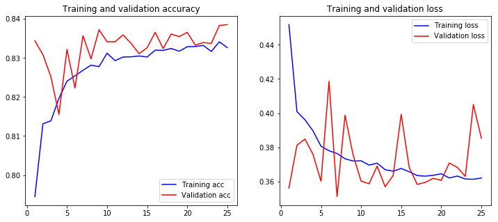

```python
result = model.fit(X_train, y_train ,epochs=25, batch_size=128, validation_split=0.2, shuffle=True)

print("Training Accuracy: ")
print(model.evaluate(X_train, y_train, verbose=0))
print('-'*10)
print("Validate Accuracy: ")
print(model.evaluate(X_test, y_test, verbose=0))

plot_history(result)
```

```python
model.save('model/SimpleMLP.h5')
```

# 2.2 機器學習模型

- 決策樹
- 隨機森林
- adaboost
- GBDT
- XGBoost
- Extratree
- 再以Grid Search處理參數，最後以Grid模型做ensemble模型。

```python
classifiers = [
    DecisionTreeClassifier(),
    RandomForestClassifier(),
    AdaBoostClassifier(),
    GradientBoostingClassifier(),
    xgb.XGBClassifier(),
    ExtraTreesClassifier()
]
```

```python
# Logging for Visual Comparison
# log_cols=["Classifier", "Accuracy", "Log Loss"]
log_cols=["Classifier", "Accuracy"]
# log = pd.DataFrame([['DNN', DNN_acc*100,DNN_loss]],columns=log_cols)

DNN_acc = accuracy_score(y_test, model.predict_classes(X_test))

log = pd.DataFrame([['DNN', DNN_acc*100]],columns=log_cols)

base_predictions_train = pd.DataFrame()
oof_X_train = pd.DataFrame()
oof_X_test = pd.DataFrame()

for clf in classifiers:

    name = clf.__class__.__name__
    clf.fit(X_train, y_train.values.ravel())
    model_name = 'model/'+ name +'_00001.pkl'
    joblib.dump(clf, model_name)
    print("="*30)
    print(name)

    train_predictions = clf.predict(X_test)
    acc = accuracy_score(y_test, train_predictions)

#     oof_train, oof_test = get_oof(clf, X_train, y_train, X_test)
#     base_predictions_train[name] = oof_train.ravel()
#     oof_X_train[name] = oof_train.ravel()
#     oof_X_test[name] = oof_test.ravel()
    print("Accuracy: {:.2%}".format(acc))

    log_entry = pd.DataFrame([[name, acc*100]], columns=log_cols)
    log = log.append(log_entry)

    # Grid Search
    name = clf.__class__.__name__ + 'Grid'
    print("="*30)
    print(name)
    clf, train_predictions = grid_classifier(clf)
    print('-'*10)
    print('Start get oof')
    oof_train, oof_test = get_oof(clf, X_train, y_train, X_test)
    base_predictions_train[name] = oof_train.ravel()
    oof_X_train[name] = oof_train.ravel()
    oof_X_test[name] = oof_test.ravel()

    acc = accuracy_score(y_test, train_predictions)
    print("Accuracy: {:.2%}".format(acc))
    log_entry = pd.DataFrame([[name, acc*100]], columns=log_cols)
    log = log.append(log_entry)

print("="*30)
```

```
==============================
DecisionTreeClassifier
Accuracy: 76.36%
==============================
DecisionTreeClassifierGrid
{'max_depth': [2, 3, 4, 5, 6, 7, 8, 9], 'min_samples_split': [2, 3, 4, 5, 6, 7, 8, 9]}
-----
Get Grid Parameters
{'class_weight': None, 'criterion': 'gini', 'max_depth': 7, 'max_features': None, 'max_leaf_nodes': None, 'min_impurity_decrease': 0.0, 'min_impurity_split': None, 'min_samples_leaf': 1, 'min_samples_split': 7, 'min_weight_fraction_leaf': 0.0, 'presort': False, 'random_state': None, 'splitter': 'bes…
----------
Start get oof
Accuracy: 81.94%
==============================
RandomForestClassifier
Accuracy: 79.77%
==============================
RandomForestClassifierGrid
{'n_estimators': [100, 150, 200], 'criterion': ['entropy', 'gini'], 'n_jobs': [-1], 'verbose': [1]}
```

```
[Parallel(n_jobs=-1)]: Done  34 tasks      | elapsed:    0.1s
[Parallel(n_jobs=-1)]: Done 184 tasks      | elapsed:    1.0s
[Parallel(n_jobs=-1)]: Done 200 out of 200 | elapsed:    1.1s finished
```

```
-----
Get Grid Parameters
{'bootstrap': True, 'class_weight': None, 'criterion': 'entropy', 'max_depth': None, 'max_features': 'auto', 'max_leaf_nodes': None, 'min_impurity_decrease': 0.0, 'min_impurity_split': None, 'min_samples_leaf': 1, 'min_samples_split': 2, 'min_weight_fraction_leaf': 0.0, 'n_estimators': 200, 'n_jobs'…
```

[output not shown]

```
----------
Start get oof
```

[output not shown]

```
Accuracy: 79.85%
==============================
AdaBoostClassifier
Accuracy: 83.06%
==============================
AdaBoostClassifierGrid
{'n_estimators': [150, 200], 'algorithm': ['SAMME', 'SAMME.R'], 'learning_rate': [0.2, 0.5, 0.9]}
-----
Get Grid Parameters
{'algorithm': 'SAMME.R', 'base_estimator': None, 'learning_rate': 0.9, 'n_estimators': 150, 'random_state': None}
----------
Start get oof
Accuracy: 82.89%
==============================
GradientBoostingClassifier
Accuracy: 83.05%
==============================
GradientBoostingClassifierGrid
{'loss': ['deviance'], 'learning_rate': [0.2, 0.5, 0.9], 'max_depth': [3, 8]}
-----
Get Grid Parameters
{'criterion': 'friedman_mse', 'init': None, 'learning_rate': 0.2, 'loss': 'deviance', 'max_depth': 3, 'max_features': None, 'max_leaf_nodes': None, 'min_impurity_decrease': 0.0, 'min_impurity_split': None, 'min_samples_leaf': 1, 'min_samples_split': 2, 'min_weight_fraction_leaf': 0.0, 'n_estimators'…
----------
Start get oof
Accuracy: 83.11%
==============================
XGBClassifier
Accuracy: 83.06%
==============================
XGBClassifierGrid
{'learning_rate': [0.2, 0.5, 0.9], 'gamma': array([0.  , 0.45, 0.9 ]), 'objective': ['binary:logistic']}
-----
Get Grid Parameters
{'base_score': 0.5, 'booster': 'gbtree', 'colsample_bylevel': 1, 'colsample_bytree': 1, 'gamma': 0.0, 'learning_rate': 0.2, 'max_delta_step': 0, 'max_depth': 3, 'min_child_weight': 1, 'missing': None, 'n_estimators': 100, 'n_jobs': 1, 'nthread': None, 'objective': 'binary:logistic', 'random_state': …
----------
Start get oof
Accuracy: 83.35%
==============================
ExtraTreesClassifier
Accuracy: 79.19%
==============================
ExtraTreesClassifierGrid
{'n_estimators': [100, 150, 200], 'criterion': ['entropy', 'gini']}
-----
Get Grid Parameters
{'bootstrap': False, 'class_weight': None, 'criterion': 'entropy', 'max_depth': None, 'max_features': 'auto', 'max_leaf_nodes': None, 'min_impurity_decrease': 0.0, 'min_impurity_split': None, 'min_samples_leaf': 1, 'min_samples_split': 2, 'min_weight_fraction_leaf': 0.0, 'n_estimators': 100, 'n_jobs…
----------
Start get oof
Accuracy: 79.09%
==============================
```

```python
data = [
    go.Heatmap(
        z= base_predictions_train.astype(float).corr().values ,
        x=base_predictions_train.columns.values,
        y= base_predictions_train.columns.values,
          colorscale='Portland',
            showscale=True,
            reversescale = True
    )
]
py.iplot(data, filename='labelled-heatmap')
```

[interactive chart not shown]

```python
step_two = xgb.XGBClassifier().fit(oof_X_train, y_train.values.ravel())
y_pred = step_two.predict(oof_X_test)

predictions = [round(value) for value in y_pred]
accuracy = accuracy_score(y_test, predictions)
print(accuracy)
log_entry = pd.DataFrame([['Ensemble_All', accuracy*100]], columns=log_cols)
log = log.append(log_entry)

thresholds = sorted(step_two.feature_importances_, reverse=True)
for thresh in thresholds:
    # select features using threshold
    selection = SelectFromModel(step_two, threshold=thresh, prefit=True)
    select_X_train = selection.transform(oof_X_train)
    # train model
    selection_model = xgb.XGBClassifier()
    selection_model.fit(select_X_train, y_train.values.ravel())
    # eval model
    select_X_test = selection.transform(oof_X_test)
    y_pred = selection_model.predict(select_X_test)
    predictions = [round(value) for value in y_pred]
    accuracy = accuracy_score(y_test, predictions)
    print("Thresh=%.3f, n=%d, Accuracy: %.2f%%" % (thresh, select_X_train.shape[1], accuracy*100.0))

print(step_two.feature_importances_)
```

```
0.8315078308936431
Thresh=0.533, n=1, Accuracy: 83.12%
Thresh=0.248, n=2, Accuracy: 83.16%
Thresh=0.088, n=3, Accuracy: 83.25%
Thresh=0.068, n=4, Accuracy: 83.24%
Thresh=0.048, n=5, Accuracy: 83.22%
Thresh=0.016, n=6, Accuracy: 83.15%
[0.01618086 0.04754992 0.08770299 0.53260916 0.24759929 0.0683578 ]
```

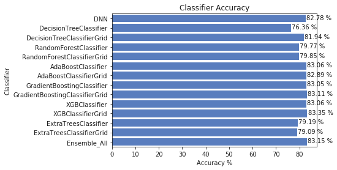

```python
sns.set_color_codes("muted")
g=sns.barplot(x='Accuracy', y='Classifier', data=log, color="b")

plt.xlabel('Accuracy %')
plt.title('Classifier Accuracy')

for p in g.patches:
    x = p.get_x() + p.get_width() +.3
    y = p.get_y() + p.get_height()/2 + .1
    g.annotate("%.2f %%" % (p.get_width()), (x, y))

plt.show()
```

```python
# model_name = 'model/'+clf.__class__.__name__+'_00001.pkl'
# print('Loading ' + model_name)
# clf = joblib.load(model_name)
# scaler = joblib.load(scaler_filename)

# input_dt = [37,1,3,130,250,1,0,187,0,2.3,0,0,1]
# input_dt = np.array(input_dt).reshape(1, -1)
# input_dt = scaler.transform(input_dt)
# train_predictions = clf.predict(input_dt)

# print(train_predictions)
```

```python
# model_api = load_model('model/SimpleMLP.h5')
# print(model.evaluate(X_test, y_test, verbose=1))
# print(model_api.evaluate(X_test, y_test, verbose=1))
```